# An Analysis of Property Damage Caused by Tornadoes

# Group members

> Nuqman Iskandar, Gaurav Capila, Yuthika Goel, Janet Seidl

# Introduction

In recent years climate change has been linked to more extreme weather events around the world, from hurricanes to wildfires. Among these, tornadoes are one of the most unpredictable and destructive in the US. Given the growing concern about economic loss and disaster preparedness, it’s important to know if tornadoes are getting more severe.

Our question is: Has the average property loss from tornadoes in the US increased from 1950 to 1995? We will look at the relationship between the year a tornado occurred and the average property loss it caused.

# Background

We will be focusing on the yr and loss variables.

- The yr variable is the year when the tornado took place (1950-1995)
- The loss variable represents the estimated property loss in dollars from the tornado. A higher value indicates more loss and we will be using this as our indicator for how severe a tornado is.

The representation of the loss variable changes throughout the dataset. From 1950 - 1995, the variable is represented by a categorization of tornado damage with each category being an order of magnitude larger than the previous. Starting in 1996, they instead recorded the variable in millions of dollars and in 2016 switched to whole dollar amounts. In order to keep the larger part of our data, we are focusing on 1950 - 1995 since there is not an accurate way to switch the values from categories to dollar amounts. This will also help reduce the affect inflation has on our analysis.

Focusing on our desired time frame and looking at the average property loss caused by tornadoes, we get the following scatter plot.

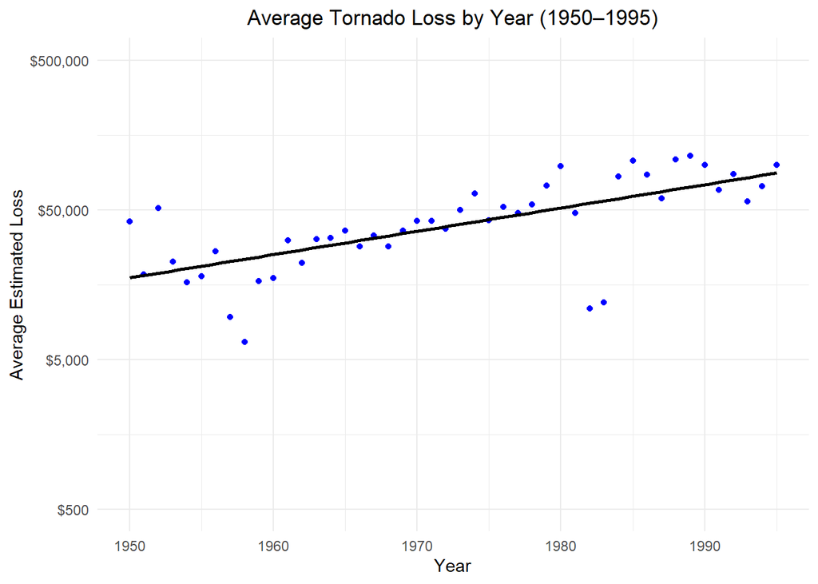

The scatter plot displays the average estimated property loss from tornadoes by year from 1950 to 1995. Each point represents the mean property loss of tornadoes that occurred in a given year.The upward sloping regression line suggests an increasing trend in average loss over time. This may indicate that tornadoes have become more economically damaging, possibly due to factors such as there are now more buildings in areas where tornadoes are reported and also improved damage reporting methods.

# Analysis

To formally assess whether tornado losses have significantly increased over years, we use simple linear regression.

## Model Statement

$Y$ = average estimated property loss from tornadoes in a given year

$X$ = year (from 1950 to 1995)

We model this relationship as:

$Y = \beta_0 + \beta_1 X + \epsilon$ Where:

$\beta_0$ is the intercept

$\beta_1$ is the slope, representing the change in average property loss per year

$\epsilon$ is the error term

## Assumptions

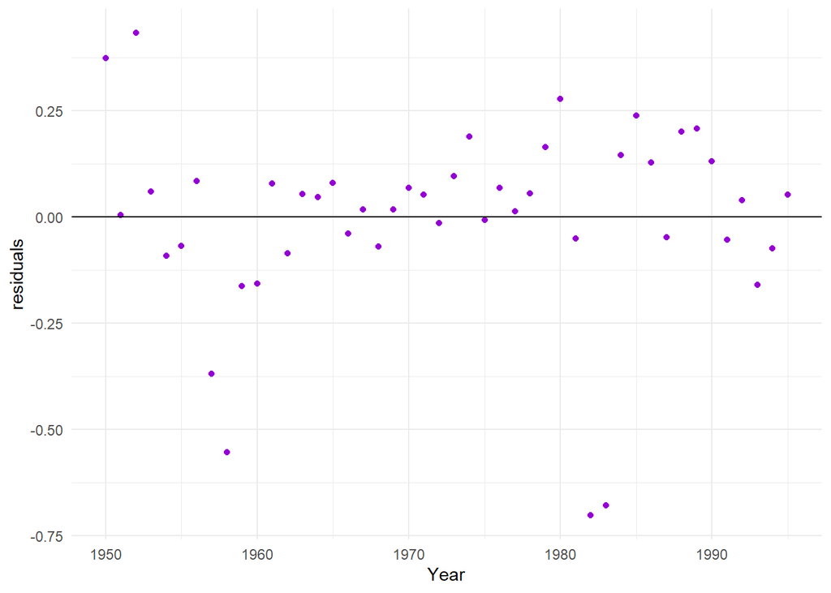

## Hypothesis Testing

We will test the following hypothesis with $\alpha = 0.05$

$H_0$: $\beta_1 = 0$ meaning there is no trend in average tornado loss over time

$H_A$: $\beta_1 > 0$ meaning there is a positive in average tornado loss over time

We are interested in the presence of a positive linear relationship between the two variables. Hence, we will use a one-sided alternative hypothesis test.

## Outcomes

```
##
## Call:
## lm(formula = avg_loss ~ yr, data = avg_loss_by_year)
##
## Residuals:
##      Min       1Q   Median       3Q      Max
## -0.70286 -0.06400  0.04357  0.09354  0.43350
##
## Coefficients:
##               Estimate Std. Error t value Pr(>|t|)
## (Intercept) -26.809158   4.938199  -5.429 2.31e-06 ***
## yr            0.015566   0.002503   6.218 1.61e-07 ***
## ---
## Signif. codes:  0 '***' 0.001 '**' 0.01 '*' 0.05 '.' 0.1 ' ' 1
##
## Residual standard error: 0.2254 on 44 degrees of freedom
## Multiple R-squared:  0.4677, Adjusted R-squared:  0.4556
## F-statistic: 38.66 on 1 and 44 DF,  p-value: 1.613e-07
```

```
## [1] 6.218937
```

Our test statistic was 6.218

```
## [1] 8.039372e-08
```

Our p-value was 8.039372e-08 which is very small and substantially smaller than our significance value of 0.05.

## Interpretation

Based on the regression output, the p-value for $\beta_1 < 0.05$, which means we reject the null hypothesis and conclude that the average estimated loss from tornadoes has increased over time.

# Discussion

From the interpretation, there is enough evidence to reject our null hypothesis, which means we can conclude the average estimated loss from tornadoes increased from 1950 to 1995.

While this could suggest that tornadoes are getting more severe and destructive, there could be several other factors that influence our analysis. Recorded property losses may have risen due to inflation, better reporting, or greater infrastructure development in rural areas. No matter the reason, our finding highlights that tornadoes potentially cause more economic damage now than in the past.

## Shortcomings

While our data provide valuables insights, there are some shortcomings that needed to be point out.

- The variables do not meet the assumption that the relationship between year and average estimated loss from tornadoes are linear. From the residual plots we can see the curved pattern which suggest that the linearity assumptions is violated.
- To utilize the larger part of our data, we chose to use the time period where the the estimated property loss was represented categorically with each category being an order of magnitude larger than the previous. This means that there is some pretty large intervals that fall under the same category. For example, when the loss value is a 5, the estimated property loss falls in the range of 50,000 to 500,0000.

# Reference

1. 1950-2023_actual_tornadoes.csv from the National Oceanic and Atmospheric Administration at https://www.spc.noaa.gov/wcm/#data